# Translocations dose estimation

## Load pre-calculated curve

The first step is to either load the pre-calculated curve in `.rds` format obtained in the dose-effect fitting module or input the curve coefficients manually. Clicking on “Preview data” will load the curve into the app and display it on the “Results” tabbed box. If coefficients are entered manually, a irradiation conditions tab will appear to fill with corresponding information.

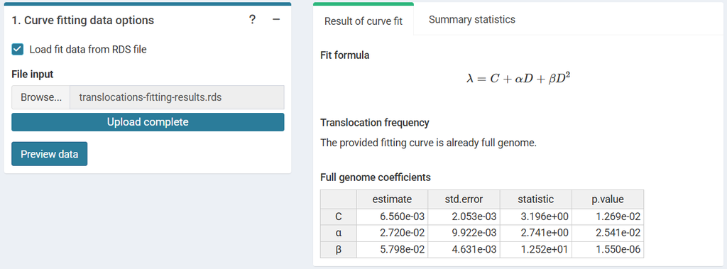

‘Curve fitting data options’ box and ‘Results’ tabbed box in the dose estimation module when loading curve from an `.rds` file.

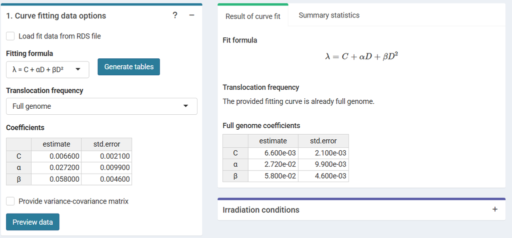

‘Curve fitting data options’ box and ‘Results’ tabbed box in the dose estimation module when inputting curve coefficients manually. Note that if no variance-covariance matrix is provided, only the variances calculated from the coefficients’ standard errors will be used in calculations.

This step is accomplished in R by either using the results from `fit()` or by loading an existing `.rds` object via `readRDS()`:

```r
fit_results <- system.file("extdata", "translocations-fitting-results.rds",
    package = "biodosetools") %>%
    readRDS()
```

```r
fit_results$fit_coeffs
```

```
#>                estimate   std.error statistic      p.value
#> coeff_C     0.006560406 0.002052834  3.195780 1.269259e-02
#> coeff_alpha 0.027197296 0.009922177  2.741061 2.540751e-02
#> coeff_beta  0.057982322 0.004630926 12.520675 1.550057e-06
```

## Calculate genomic conversion factor

To be able to fit the equivalent full genome case data, we need to calculate the genomic conversion factor.

To do this, in the “Stain color options” box we select the sex of the individual, and the list of chromosomes and stains used for the translocation assay. Clicking on “Generate table” will show a table in the “Chromosome data” box in which we select the chromosome-stain pairs. Clicking on the “Calculate fraction” will calculate the genomic conversion factor.

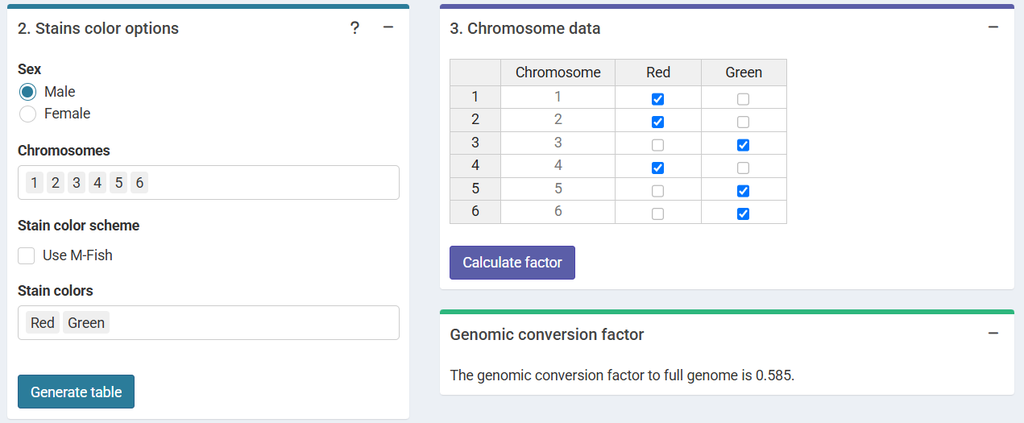

‘Stains color options’, ‘Chromosome data’ and ‘Genomic conversion factor’ boxes in the dose estimation module.

To calculate the genomic conversion factor in R we call the `calculate_genome_factor()` function:

```r
genome_factor <- calculate_genome_factor(
  dna_table = dna_content_fractions_morton,
  chromosome = c(1, 2, 3, 4, 5, 6),
  color = c("Red", "Red", "Green", "Red", "Green", "Green"),
  sex = "male"
)
```

```r
genome_factor
```

```
#> [1] 0.5847343
```

## Input case data

Next we can choose to either load the case data from a file (supported formats are `.csv`, `.dat`, and `.txt`) or to input the data manually. If needed, the user can select to use confounders (either using Sigurdson’s method, or by inputting the translocation frequency per cell). Once the table is generated and filled, the “Calculate parameters” button will calculate the total number of cells ($N$), total number of aberrations ($X$), as well as mean ($\bar{F}_{p}$), standard error ($\sigma_{p}$), dispersion index ($\sigma^{2}/\bar{y}$), $u$-value, expected translocation rate ($X_{c}$), full genome mean ($\bar{F}_{g}$), and full genome error ($\sigma_{g}$). An ID column will also appear to identify each case. Multiple cases are supported.

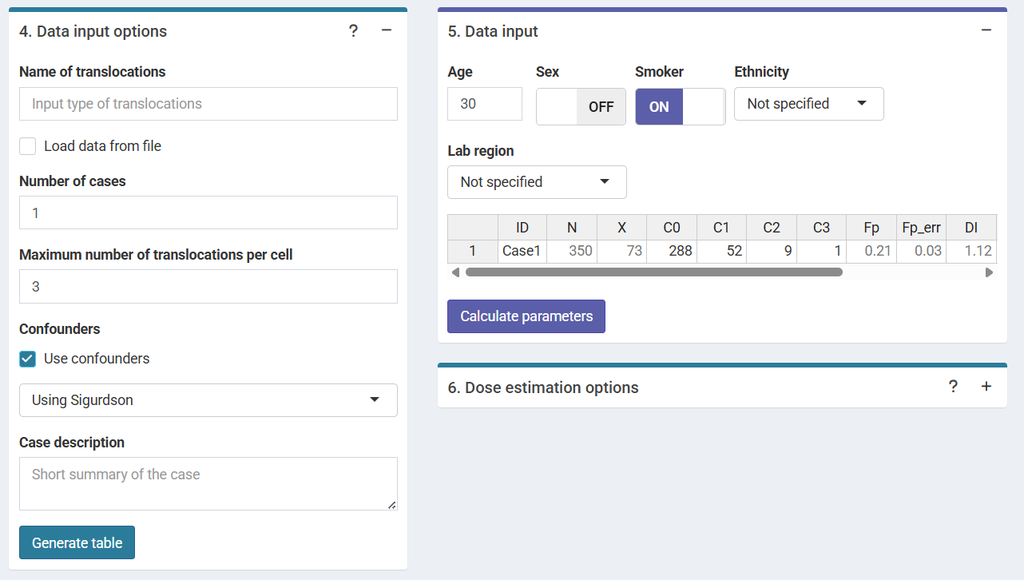

‘Data input options’ and ‘Data input’ boxes in the dose estimation module.

This step is accomplished in R by calling the `calculate_aberr_table()` function:

```r
case_data <- data.frame(
  ID = 'Case1', C0 = 288, C1 = 52, C2 = 9, C3 = 1
) %>%
  calculate_aberr_table(
    type = "case",
    assessment_u = 1,
    aberr_module = "translocations"
  ) %>%
  dplyr::mutate(
    Xc = calculate_trans_rate_sigurdson(
      cells = N,
      genome_factor = genome_factor,
      age_value = 30,
      smoker_bool = TRUE
    ),
    Fg = (X - Xc) / (N * genome_factor),
    Fg_err = Fp_err / sqrt(genome_factor)
  )
```

```r
case_data
```

```
#> # A tibble: 1 × 14
#>   ID        N     X    C0    C1    C2    C3    Fp Fp_err    DI     u    Xc    Fg
#>   <chr> <int> <int> <int> <int> <int> <int> <dbl>  <dbl> <dbl> <dbl> <dbl> <dbl>
#> 1 Case1   350    73   288    52     9     1 0.209 0.0259  1.12  1.64  1.02 0.352
#> # ℹ 1 more variable: Fg_err <dbl>
```

## Perform dose estimation

The final step is to select the dose estimation options. In the “Dose estimation options” box we can select type of exposure (acute, protracted or highly protracted), type of assessment (whole-body, partial-body or heterogeneous), and error methods for each type of assessment (Merkle’s method or Delta method). Heterogeneous assessment available for single case only.

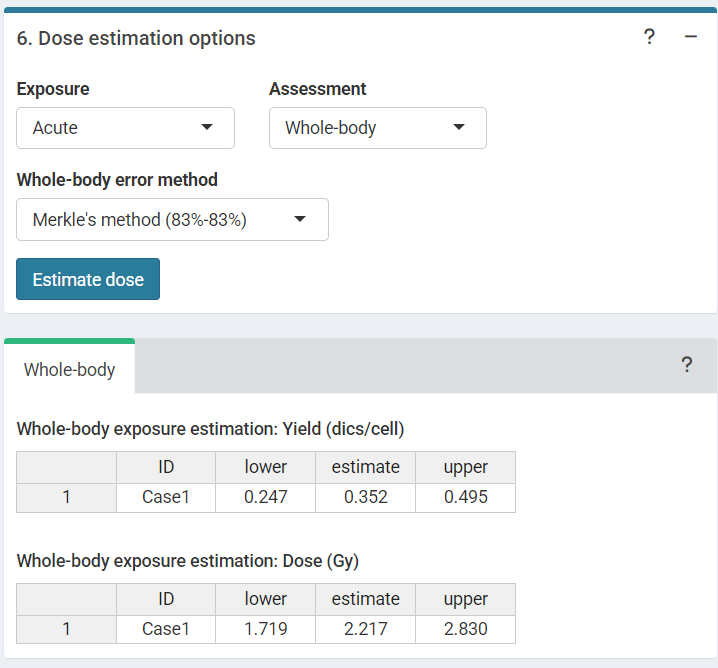

‘Dose estimation options’ box in the dose estimation module.

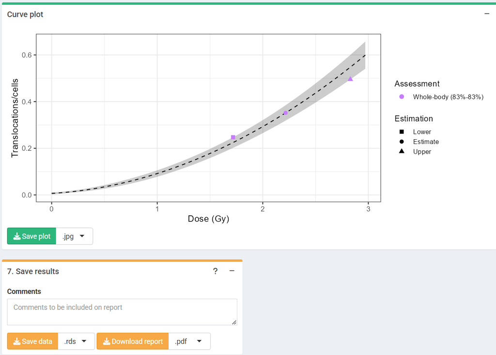

‘Results’ tabbed box, ‘Curve plot’ and ‘Save results’ boxes in the dose estimation module.

```r
fit_coeffs <- fit_results[["fit_coeffs"]]
fit_var_cov_mat <- fit_results[["fit_var_cov_mat"]]
```

```r
results_whole_merkle <- estimate_whole_body_merkle(
  num_cases = 1,
  case_data,
  fit_coeffs,
  fit_var_cov_mat,
  conf_int_yield = 0.83,
  conf_int_curve = 0.83,
  protracted_g_value = 1,
  genome_factor,
  aberr_module = "translocations"
)
```

To visualize the estimated doses, we call the `plot_estimated_dose_curve()` function:

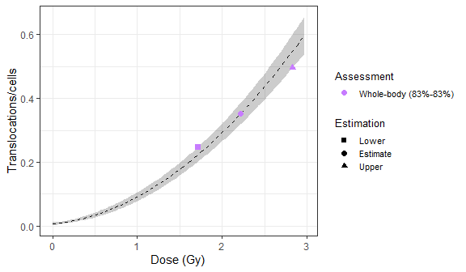

Plot of estimated doses generated by {biodosetools}. The grey shading indicates the uncertainties associated with the calibration curve.

```r
plot_estimated_dose_curve(
  est_doses = list(whole = results_whole_merkle),
  fit_coeffs,
  fit_var_cov_mat,
  protracted_g_value = 1,
  conf_int_curve = 0.83,
  aberr_name = "Translocations",
  place = "UI"
)
```